# Risk Factor Analysis

## Outcome Variable

**Outcome Variable:** haz

## Predictor Variables

**Intervention Variable:** exclfeed6

**Adjustment Set:**

- arm
- sex
- brthmon
- W_mage
- meducyrs
- feducyrs
- hhwealth_quart
- hfoodsec
- W_mhtcm
- W_mwtkg
- W_mbmi
- vagbrth
- W_gagebrth
- W_birthwt
- W_birthlen
- W_nrooms
- W_nchldlt5
- month
- W_parity
- impfloor
- impsan
- safeh20
- delta_W_mage
- delta_meducyrs
- delta_feducyrs
- delta_hhwealth_quart
- delta_hfoodsec
- delta_W_mhtcm
- delta_W_mwtkg
- delta_W_mbmi
- delta_vagbrth
- delta_W_gagebrth
- delta_W_birthwt
- delta_W_birthlen
- delta_W_nrooms
- delta_W_nchldlt5
- delta_month
- delta_W_parity
- delta_impfloor
- delta_impsan
- delta_safeh20

## Stratifying Variables

The analysis was stratified on these variable(s):

- agecat
- studyid
- country

## Data Summary

| agecat | studyid | country | exclfeed6 | n_cell | n |
| --- | --- | --- | --- | --- | --- |
| Birth | ki0047075b-MAL-ED | BANGLADESH | 1 | 31 | 205 |
| Birth | ki0047075b-MAL-ED | BANGLADESH | 0 | 174 | 205 |
| Birth | ki0047075b-MAL-ED | BRAZIL | 1 | 2 | 60 |
| Birth | ki0047075b-MAL-ED | BRAZIL | 0 | 58 | 60 |
| Birth | ki0047075b-MAL-ED | INDIA | 1 | 1 | 39 |
| Birth | ki0047075b-MAL-ED | INDIA | 0 | 38 | 39 |
| Birth | ki0047075b-MAL-ED | NEPAL | 1 | 2 | 24 |
| Birth | ki0047075b-MAL-ED | NEPAL | 0 | 22 | 24 |
| Birth | ki0047075b-MAL-ED | PERU | 1 | 2 | 213 |
| Birth | ki0047075b-MAL-ED | PERU | 0 | 211 | 213 |
| Birth | ki0047075b-MAL-ED | SOUTH AFRICA | 1 | 0 | 91 |
| Birth | ki0047075b-MAL-ED | SOUTH AFRICA | 0 | 91 | 91 |
| Birth | ki0047075b-MAL-ED | TANZANIA, UNITED REPUBLIC OF | 1 | 0 | 113 |
| Birth | ki0047075b-MAL-ED | TANZANIA, UNITED REPUBLIC OF | 0 | 113 | 113 |
| Birth | ki1000108-CMC-V-BCS-2002 | INDIA | 1 | 7 | 7 |
| Birth | ki1000108-CMC-V-BCS-2002 | INDIA | 0 | 0 | 7 |
| Birth | ki1000108-IRC | INDIA | 1 | 0 | 14 |
| Birth | ki1000108-IRC | INDIA | 0 | 14 | 14 |
| Birth | ki1000109-EE | PAKISTAN | 1 | 38 | 42 |
| Birth | ki1000109-EE | PAKISTAN | 0 | 4 | 42 |
| Birth | ki1000304b-SAS-CompFeed | INDIA | 1 | 346 | 364 |
| Birth | ki1000304b-SAS-CompFeed | INDIA | 0 | 18 | 364 |
| Birth | ki1017093b-PROVIDE | BANGLADESH | 1 | 159 | 539 |
| Birth | ki1017093b-PROVIDE | BANGLADESH | 0 | 380 | 539 |
| Birth | ki1101329-Keneba | GAMBIA | 1 | 6 | 12 |
| Birth | ki1101329-Keneba | GAMBIA | 0 | 6 | 12 |
| Birth | ki1113344-GMS-Nepal | NEPAL | 1 | 419 | 563 |
| Birth | ki1113344-GMS-Nepal | NEPAL | 0 | 144 | 563 |
| Birth | kiGH5241-JiVitA-3 | BANGLADESH | 1 | 12302 | 15793 |
| Birth | kiGH5241-JiVitA-3 | BANGLADESH | 0 | 3491 | 15793 |

[output cut: 70 more lines]

The following strata were considered:

- agecat: 24 months, studyid: ki0047075b-MAL-ED, country: BANGLADESH
- agecat: 24 months, studyid: ki0047075b-MAL-ED, country: BRAZIL
- agecat: 24 months, studyid: ki0047075b-MAL-ED, country: INDIA
- agecat: 24 months, studyid: ki0047075b-MAL-ED, country: NEPAL
- agecat: 24 months, studyid: ki0047075b-MAL-ED, country: PERU
- agecat: 24 months, studyid: ki0047075b-MAL-ED, country: SOUTH AFRICA
- agecat: 24 months, studyid: ki0047075b-MAL-ED, country: TANZANIA, UNITED REPUBLIC OF
- agecat: 24 months, studyid: ki1000108-CMC-V-BCS-2002, country: INDIA
- agecat: 24 months, studyid: ki1000108-IRC, country: INDIA
- agecat: 24 months, studyid: ki1000109-EE, country: PAKISTAN
- agecat: 24 months, studyid: ki1017093b-PROVIDE, country: BANGLADESH
- agecat: 24 months, studyid: ki1101329-Keneba, country: GAMBIA
- agecat: 24 months, studyid: ki1113344-GMS-Nepal, country: NEPAL
- agecat: 24 months, studyid: ki1148112-LCNI-5, country: MALAWI
- agecat: 24 months, studyid: kiGH5241-JiVitA-3, country: BANGLADESH
- agecat: 24 months, studyid: kiGH5241-JiVitA-4, country: BANGLADESH
- agecat: 6 months, studyid: ki0047075b-MAL-ED, country: BANGLADESH
- agecat: 6 months, studyid: ki0047075b-MAL-ED, country: BRAZIL
- agecat: 6 months, studyid: ki0047075b-MAL-ED, country: INDIA
- agecat: 6 months, studyid: ki0047075b-MAL-ED, country: NEPAL
- agecat: 6 months, studyid: ki0047075b-MAL-ED, country: PERU
- agecat: 6 months, studyid: ki0047075b-MAL-ED, country: SOUTH AFRICA
- agecat: 6 months, studyid: ki0047075b-MAL-ED, country: TANZANIA, UNITED REPUBLIC OF
- agecat: 6 months, studyid: ki1000108-CMC-V-BCS-2002, country: INDIA
- agecat: 6 months, studyid: ki1000108-IRC, country: INDIA
- agecat: 6 months, studyid: ki1000109-EE, country: PAKISTAN
- agecat: 6 months, studyid: ki1000304b-SAS-CompFeed, country: INDIA
- agecat: 6 months, studyid: ki1000304b-SAS-FoodSuppl, country: INDIA
- agecat: 6 months, studyid: ki1017093b-PROVIDE, country: BANGLADESH
- agecat: 6 months, studyid: ki1101329-Keneba, country: GAMBIA
- agecat: 6 months, studyid: ki1113344-GMS-Nepal, country: NEPAL
- agecat: 6 months, studyid: ki1148112-LCNI-5, country: MALAWI
- agecat: 6 months, studyid: kiGH5241-JiVitA-3, country: BANGLADESH
- agecat: 6 months, studyid: kiGH5241-JiVitA-4, country: BANGLADESH
- agecat: Birth, studyid: ki0047075b-MAL-ED, country: BANGLADESH
- agecat: Birth, studyid: ki0047075b-MAL-ED, country: BRAZIL
- agecat: Birth, studyid: ki0047075b-MAL-ED, country: INDIA
- agecat: Birth, studyid: ki0047075b-MAL-ED, country: NEPAL
- agecat: Birth, studyid: ki0047075b-MAL-ED, country: PERU
- agecat: Birth, studyid: ki0047075b-MAL-ED, country: SOUTH AFRICA
- agecat: Birth, studyid: ki0047075b-MAL-ED, country: TANZANIA, UNITED REPUBLIC OF
- agecat: Birth, studyid: ki1000108-CMC-V-BCS-2002, country: INDIA
- agecat: Birth, studyid: ki1000108-IRC, country: INDIA
- agecat: Birth, studyid: ki1000109-EE, country: PAKISTAN
- agecat: Birth, studyid: ki1000304b-SAS-CompFeed, country: INDIA
- agecat: Birth, studyid: ki1017093b-PROVIDE, country: BANGLADESH
- agecat: Birth, studyid: ki1101329-Keneba, country: GAMBIA
- agecat: Birth, studyid: ki1113344-GMS-Nepal, country: NEPAL
- agecat: Birth, studyid: kiGH5241-JiVitA-3, country: BANGLADESH
- agecat: Birth, studyid: kiGH5241-JiVitA-4, country: BANGLADESH

### Dropped Strata

Some strata were dropped due to rare outcomes:

- agecat: Birth, studyid: ki0047075b-MAL-ED, country: BRAZIL
- agecat: Birth, studyid: ki0047075b-MAL-ED, country: INDIA
- agecat: Birth, studyid: ki0047075b-MAL-ED, country: NEPAL
- agecat: Birth, studyid: ki0047075b-MAL-ED, country: PERU
- agecat: Birth, studyid: ki0047075b-MAL-ED, country: SOUTH AFRICA
- agecat: Birth, studyid: ki0047075b-MAL-ED, country: TANZANIA, UNITED REPUBLIC OF
- agecat: Birth, studyid: ki1000108-CMC-V-BCS-2002, country: INDIA
- agecat: Birth, studyid: ki1000108-IRC, country: INDIA
- agecat: Birth, studyid: ki1000109-EE, country: PAKISTAN
- agecat: 6 months, studyid: ki0047075b-MAL-ED, country: INDIA
- agecat: 6 months, studyid: ki0047075b-MAL-ED, country: SOUTH AFRICA
- agecat: 6 months, studyid: ki0047075b-MAL-ED, country: TANZANIA, UNITED REPUBLIC OF
- agecat: 6 months, studyid: ki1000108-CMC-V-BCS-2002, country: INDIA
- agecat: 6 months, studyid: ki1000108-IRC, country: INDIA
- agecat: 6 months, studyid: ki1000304b-SAS-FoodSuppl, country: INDIA
- agecat: 24 months, studyid: ki0047075b-MAL-ED, country: INDIA
- agecat: 24 months, studyid: ki0047075b-MAL-ED, country: PERU
- agecat: 24 months, studyid: ki0047075b-MAL-ED, country: SOUTH AFRICA
- agecat: 24 months, studyid: ki0047075b-MAL-ED, country: TANZANIA, UNITED REPUBLIC OF
- agecat: 24 months, studyid: ki1000108-CMC-V-BCS-2002, country: INDIA
- agecat: 24 months, studyid: ki1000108-IRC, country: INDIA
- agecat: 24 months, studyid: ki1000109-EE, country: PAKISTAN

## Methods Detail

We’re interested in the causal parameters $E[Y_a]$ for all values of $a \in \mathcal{A}$. These parameters represent the mean outcome if, possibly contrary to fact, we intervened to set all units to have $A=a$. Under the randomization and positivity assumptions, these are identified by the statistical parameters $\psi_a=E_W[E_{Y|A,W}(Y|A=a,W)]$. In addition, we’re interested in the mean of $Y$, $E[Y]$ under no intervention (the observed mean). We will estimate these parameters by using SuperLearner to fit the relevant likelihood factors – $E_{Y|A,W}(Y|A=a,W)$ and $p(A=a|W)$, and then updating our likelihood fit using a joint TMLE.

For unadjusted analyses ($W=\{\}$), initial likelihoods were estimated using Lrnr_glm to estimate the simple $E(Y|A)$ and Lrnr_mean to estimate $p(A)$. For adjusted analyses, a small library containing Lrnr_glmnet, Lrnr_xgboost, and Lrnr_mean was used.

Having estimated these parameters, we will then use the delta method to estimate relative risks and attributable risks relative to a prespecified baseline level of $A$.

# Results Detail

## Results Plots

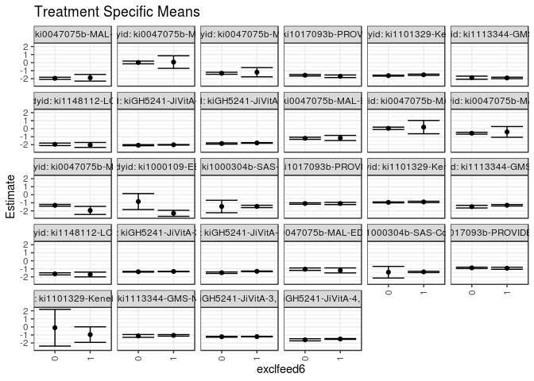

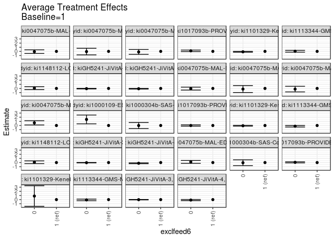

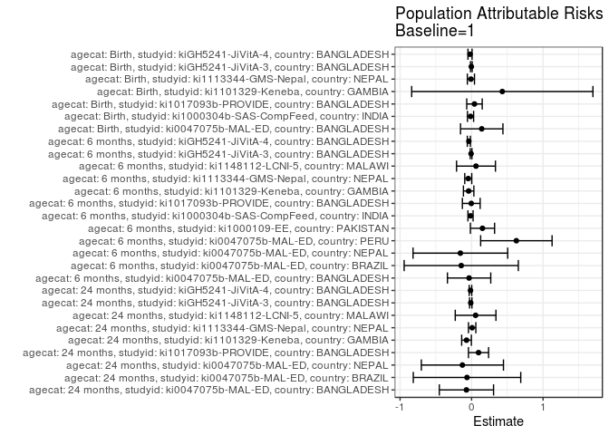

## Results Table

### Parameter: TSM

| agecat | studyid | country | intervention_level | baseline_level | estimate | ci_lower | ci_upper |
| --- | --- | --- | --- | --- | --- | --- | --- |
| Birth | ki0047075b-MAL-ED | BANGLADESH | 1 | NA | -1.1951795 | -1.5073682 | -0.8829908 |
| Birth | ki0047075b-MAL-ED | BANGLADESH | 0 | NA | -1.0415788 | -1.1947979 | -0.8883596 |
| Birth | ki1000304b-SAS-CompFeed | INDIA | 1 | NA | -1.3791683 | -1.4632120 | -1.2951246 |
| Birth | ki1000304b-SAS-CompFeed | INDIA | 0 | NA | -1.4196640 | -2.1447080 | -0.6946200 |
| Birth | ki1017093b-PROVIDE | BANGLADESH | 1 | NA | -0.9256726 | -1.0567390 | -0.7946062 |
| Birth | ki1017093b-PROVIDE | BANGLADESH | 0 | NA | -0.8771898 | -0.9635002 | -0.7908794 |
| Birth | ki1101329-Keneba | GAMBIA | 1 | NA | -0.9616667 | -1.9274750 | 0.0041417 |
| Birth | ki1101329-Keneba | GAMBIA | 0 | NA | -0.1016667 | -2.3897981 | 2.1864648 |
| Birth | ki1113344-GMS-Nepal | NEPAL | 1 | NA | -1.0549429 | -1.1521974 | -0.9576884 |
| Birth | ki1113344-GMS-Nepal | NEPAL | 0 | NA | -1.1243476 | -1.2993875 | -0.9493076 |
| Birth | kiGH5241-JiVitA-3 | BANGLADESH | 1 | NA | -1.2123758 | -1.2462908 | -1.1784607 |
| Birth | kiGH5241-JiVitA-3 | BANGLADESH | 0 | NA | -1.2284323 | -1.2818559 | -1.1750087 |
| Birth | kiGH5241-JiVitA-4 | BANGLADESH | 1 | NA | -1.5056111 | -1.5576790 | -1.4535432 |
| Birth | kiGH5241-JiVitA-4 | BANGLADESH | 0 | NA | -1.6085577 | -1.7402083 | -1.4769071 |
| 6 months | ki0047075b-MAL-ED | BANGLADESH | 1 | NA | -1.1559375 | -1.4756172 | -0.8362578 |
| 6 months | ki0047075b-MAL-ED | BANGLADESH | 0 | NA | -1.1942094 | -1.3259061 | -1.0625127 |
| 6 months | ki0047075b-MAL-ED | BRAZIL | 1 | NA | 0.1955227 | -0.6337799 | 1.0248253 |
| 6 months | ki0047075b-MAL-ED | BRAZIL | 0 | NA | 0.0434215 | -0.1023620 | 0.1892051 |
| 6 months | ki0047075b-MAL-ED | NEPAL | 1 | NA | -0.4050000 | -1.0737079 | 0.2637079 |
| 6 months | ki0047075b-MAL-ED | NEPAL | 0 | NA | -0.5652500 | -0.6822261 | -0.4482739 |
| 6 months | ki0047075b-MAL-ED | PERU | 1 | NA | -1.9530000 | -2.4531315 | -1.4528685 |
| 6 months | ki0047075b-MAL-ED | PERU | 0 | NA | -1.3147180 | -1.4252939 | -1.2041422 |
| 6 months | ki1000109-EE | PAKISTAN | 1 | NA | -2.3121318 | -2.6865239 | -1.9377397 |
| 6 months | ki1000109-EE | PAKISTAN | 0 | NA | -0.8473333 | -1.8424880 | 0.1478213 |
| 6 months | ki1000304b-SAS-CompFeed | INDIA | 1 | NA | -1.4549959 | -1.6008850 | -1.3091069 |
| 6 months | ki1000304b-SAS-CompFeed | INDIA | 0 | NA | -1.4654856 | -2.2428805 | -0.6880907 |
| 6 months | ki1017093b-PROVIDE | BANGLADESH | 1 | NA | -1.0875681 | -1.2234842 | -0.9516520 |
| 6 months | ki1017093b-PROVIDE | BANGLADESH | 0 | NA | -1.0918616 | -1.1798332 | -1.0038900 |
| 6 months | ki1101329-Keneba | GAMBIA | 1 | NA | -0.8922186 | -0.9800080 | -0.8044292 |
| 6 months | ki1101329-Keneba | GAMBIA | 0 | NA | -0.9483803 | -1.0074090 | -0.8893516 |
| 6 months | ki1113344-GMS-Nepal | NEPAL | 1 | NA | -1.3076328 | -1.3964332 | -1.2188325 |
| 6 months | ki1113344-GMS-Nepal | NEPAL | 0 | NA | -1.4830108 | -1.6507647 | -1.3152568 |
| 6 months | ki1148112-LCNI-5 | MALAWI | 1 | NA | -1.7014647 | -1.9989622 | -1.4039671 |
| 6 months | ki1148112-LCNI-5 | MALAWI | 0 | NA | -1.6262866 | -1.7577276 | -1.4948455 |
| 6 months | kiGH5241-JiVitA-3 | BANGLADESH | 1 | NA | -1.3301768 | -1.3605896 | -1.2997641 |
| 6 months | kiGH5241-JiVitA-3 | BANGLADESH | 0 | NA | -1.3608966 | -1.4103327 | -1.3114605 |
| 6 months | kiGH5241-JiVitA-4 | BANGLADESH | 1 | NA | -1.3102223 | -1.3512335 | -1.2692111 |
| 6 months | kiGH5241-JiVitA-4 | BANGLADESH | 0 | NA | -1.4798260 | -1.5721153 | -1.3875367 |
| 24 months | ki0047075b-MAL-ED | BANGLADESH | 1 | NA | -1.8863720 | -2.3016310 | -1.4711131 |
| 24 months | ki0047075b-MAL-ED | BANGLADESH | 0 | NA | -1.9544809 | -2.0882354 | -1.8207263 |
| 24 months | ki0047075b-MAL-ED | BRAZIL | 1 | NA | 0.0706983 | -0.7114477 | 0.8528442 |
| 24 months | ki0047075b-MAL-ED | BRAZIL | 0 | NA | 0.0195305 | -0.1530996 | 0.1921606 |
| 24 months | ki0047075b-MAL-ED | NEPAL | 1 | NA | -1.1950000 | -1.7707330 | -0.6192670 |
| 24 months | ki0047075b-MAL-ED | NEPAL | 0 | NA | -1.3262150 | -1.4505125 | -1.2019174 |
| 24 months | ki1017093b-PROVIDE | BANGLADESH | 1 | NA | -1.6997272 | -1.8591223 | -1.5403321 |
| 24 months | ki1017093b-PROVIDE | BANGLADESH | 0 | NA | -1.5681419 | -1.6641789 | -1.4721049 |
| 24 months | ki1101329-Keneba | GAMBIA | 1 | NA | -1.5170615 | -1.6002189 | -1.4339042 |
| 24 months | ki1101329-Keneba | GAMBIA | 0 | NA | -1.6187756 | -1.6835601 | -1.5539911 |
| 24 months | ki1113344-GMS-Nepal | NEPAL | 1 | NA | -1.9083464 | -2.0035433 | -1.8131494 |
| 24 months | ki1113344-GMS-Nepal | NEPAL | 0 | NA | -1.8784015 | -2.0724808 | -1.6843221 |
| 24 months | ki1148112-LCNI-5 | MALAWI | 1 | NA | -2.0214273 | -2.3269995 | -1.7158552 |
| 24 months | ki1148112-LCNI-5 | MALAWI | 0 | NA | -1.9493475 | -2.1077943 | -1.7909007 |
| 24 months | kiGH5241-JiVitA-3 | BANGLADESH | 1 | NA | -2.0057923 | -2.0453718 | -1.9662127 |
| 24 months | kiGH5241-JiVitA-3 | BANGLADESH | 0 | NA | -2.0584863 | -2.1250608 | -1.9919118 |
| 24 months | kiGH5241-JiVitA-4 | BANGLADESH | 1 | NA | -1.7758844 | -1.8179992 | -1.7337696 |
| 24 months | kiGH5241-JiVitA-4 | BANGLADESH | 0 | NA | -1.8442983 | -1.9218545 | -1.7667421 |

### Parameter: E(Y)

| agecat | studyid | country | intervention_level | baseline_level | estimate | ci_lower | ci_upper |
| --- | --- | --- | --- | --- | --- | --- | --- |
| Birth | ki0047075b-MAL-ED | BANGLADESH | NA | NA | -1.0530244 | -1.1913751 | -0.9146736 |
| Birth | ki1000304b-SAS-CompFeed | INDIA | NA | NA | -1.3937088 | -1.5095039 | -1.2779137 |
| Birth | ki1017093b-PROVIDE | BANGLADESH | NA | NA | -0.8851020 | -0.9601332 | -0.8100709 |
| Birth | ki1101329-Keneba | GAMBIA | NA | NA | -0.5316667 | -1.7992053 | 0.7358720 |
| Birth | ki1113344-GMS-Nepal | NEPAL | NA | NA | -1.0641208 | -1.1525364 | -0.9757052 |
| Birth | kiGH5241-JiVitA-3 | BANGLADESH | NA | NA | -1.2156259 | -1.2478377 | -1.1834141 |
| Birth | kiGH5241-JiVitA-4 | BANGLADESH | NA | NA | -1.5273138 | -1.5765339 | -1.4780937 |
| 6 months | ki0047075b-MAL-ED | BANGLADESH | NA | NA | -1.1905988 | -1.3103463 | -1.0708514 |
| 6 months | ki0047075b-MAL-ED | BRAZIL | NA | NA | 0.0510207 | -0.0930194 | 0.1950608 |
| 6 months | ki0047075b-MAL-ED | NEPAL | NA | NA | -0.5616889 | -0.6770008 | -0.4463770 |
| 6 months | ki0047075b-MAL-ED | PERU | NA | NA | -1.3264945 | -1.4355111 | -1.2174779 |
| 6 months | ki1000109-EE | PAKISTAN | NA | NA | -2.1595486 | -2.5331781 | -1.7859192 |
| 6 months | ki1000304b-SAS-CompFeed | INDIA | NA | NA | -1.4697236 | -1.6333919 | -1.3060553 |
| 6 months | ki1017093b-PROVIDE | BANGLADESH | NA | NA | -1.0916915 | -1.1661176 | -1.0172654 |
| 6 months | ki1101329-Keneba | GAMBIA | NA | NA | -0.9331108 | -0.9823173 | -0.8839043 |
| 6 months | ki1113344-GMS-Nepal | NEPAL | NA | NA | -1.3540280 | -1.4334801 | -1.2745760 |
| 6 months | ki1148112-LCNI-5 | MALAWI | NA | NA | -1.6395956 | -1.7592633 | -1.5199278 |
| 6 months | kiGH5241-JiVitA-3 | BANGLADESH | NA | NA | -1.3370052 | -1.3650190 | -1.3089913 |
| 6 months | kiGH5241-JiVitA-4 | BANGLADESH | NA | NA | -1.3482303 | -1.3866421 | -1.3098185 |
| 24 months | ki0047075b-MAL-ED | BANGLADESH | NA | NA | -1.9581707 | -2.0862906 | -1.8300508 |
| 24 months | ki0047075b-MAL-ED | BRAZIL | NA | NA | 0.0071006 | -0.1615817 | 0.1757828 |
| 24 months | ki0047075b-MAL-ED | NEPAL | NA | NA | -1.3232192 | -1.4452887 | -1.2011496 |
| 24 months | ki1017093b-PROVIDE | BANGLADESH | NA | NA | -1.6024221 | -1.6857420 | -1.5191023 |
| 24 months | ki1101329-Keneba | GAMBIA | NA | NA | -1.5876293 | -1.6406755 | -1.5345831 |
| 24 months | ki1113344-GMS-Nepal | NEPAL | NA | NA | -1.9002128 | -1.9869255 | -1.8135001 |
| 24 months | ki1148112-LCNI-5 | MALAWI | NA | NA | -1.9651323 | -2.1053230 | -1.8249415 |
| 24 months | kiGH5241-JiVitA-3 | BANGLADESH | NA | NA | -2.0173019 | -2.0536076 | -1.9809962 |
| 24 months | kiGH5241-JiVitA-4 | BANGLADESH | NA | NA | -1.7914765 | -1.8297816 | -1.7531715 |

### Parameter: ATE

| agecat | studyid | country | intervention_level | baseline_level | estimate | ci_lower | ci_upper |
| --- | --- | --- | --- | --- | --- | --- | --- |
| Birth | ki0047075b-MAL-ED | BANGLADESH | 1 | 1 | 0.0000000 | 0.0000000 | 0.0000000 |
| Birth | ki0047075b-MAL-ED | BANGLADESH | 0 | 1 | 0.1536007 | -0.1947978 | 0.5019993 |
| Birth | ki1000304b-SAS-CompFeed | INDIA | 1 | 1 | 0.0000000 | 0.0000000 | 0.0000000 |
| Birth | ki1000304b-SAS-CompFeed | INDIA | 0 | 1 | -0.0404957 | -0.7393477 | 0.6583563 |
| Birth | ki1017093b-PROVIDE | BANGLADESH | 1 | 1 | 0.0000000 | 0.0000000 | 0.0000000 |
| Birth | ki1017093b-PROVIDE | BANGLADESH | 0 | 1 | 0.0484828 | -0.0941387 | 0.1911042 |
| Birth | ki1101329-Keneba | GAMBIA | 1 | 1 | 0.0000000 | 0.0000000 | 0.0000000 |
| Birth | ki1101329-Keneba | GAMBIA | 0 | 1 | 0.8600000 | -1.6236126 | 3.3436126 |
| Birth | ki1113344-GMS-Nepal | NEPAL | 1 | 1 | 0.0000000 | 0.0000000 | 0.0000000 |
| Birth | ki1113344-GMS-Nepal | NEPAL | 0 | 1 | -0.0694046 | -0.2625837 | 0.1237744 |
| Birth | kiGH5241-JiVitA-3 | BANGLADESH | 1 | 1 | 0.0000000 | 0.0000000 | 0.0000000 |
| Birth | kiGH5241-JiVitA-3 | BANGLADESH | 0 | 1 | -0.0160565 | -0.0693502 | 0.0372372 |
| Birth | kiGH5241-JiVitA-4 | BANGLADESH | 1 | 1 | 0.0000000 | 0.0000000 | 0.0000000 |
| Birth | kiGH5241-JiVitA-4 | BANGLADESH | 0 | 1 | -0.1029466 | -0.2438392 | 0.0379461 |
| 6 months | ki0047075b-MAL-ED | BANGLADESH | 1 | 1 | 0.0000000 | 0.0000000 | 0.0000000 |
| 6 months | ki0047075b-MAL-ED | BANGLADESH | 0 | 1 | -0.0382719 | -0.3840379 | 0.3074940 |
| 6 months | ki0047075b-MAL-ED | BRAZIL | 1 | 1 | 0.0000000 | 0.0000000 | 0.0000000 |
| 6 months | ki0047075b-MAL-ED | BRAZIL | 0 | 1 | -0.1521011 | -0.9943346 | 0.6901323 |
| 6 months | ki0047075b-MAL-ED | NEPAL | 1 | 1 | 0.0000000 | 0.0000000 | 0.0000000 |
| 6 months | ki0047075b-MAL-ED | NEPAL | 0 | 1 | -0.1602500 | -0.8391120 | 0.5186120 |
| 6 months | ki0047075b-MAL-ED | PERU | 1 | 1 | 0.0000000 | 0.0000000 | 0.0000000 |
| 6 months | ki0047075b-MAL-ED | PERU | 0 | 1 | 0.6382820 | 0.1260725 | 1.1504914 |
| 6 months | ki1000109-EE | PAKISTAN | 1 | 1 | 0.0000000 | 0.0000000 | 0.0000000 |
| 6 months | ki1000109-EE | PAKISTAN | 0 | 1 | 1.4647984 | 0.4015477 | 2.5280492 |
| 6 months | ki1000304b-SAS-CompFeed | INDIA | 1 | 1 | 0.0000000 | 0.0000000 | 0.0000000 |
| 6 months | ki1000304b-SAS-CompFeed | INDIA | 0 | 1 | -0.0104897 | -0.7471588 | 0.7261794 |
| 6 months | ki1017093b-PROVIDE | BANGLADESH | 1 | 1 | 0.0000000 | 0.0000000 | 0.0000000 |
| 6 months | ki1017093b-PROVIDE | BANGLADESH | 0 | 1 | -0.0042935 | -0.1663096 | 0.1577226 |
| 6 months | ki1101329-Keneba | GAMBIA | 1 | 1 | 0.0000000 | 0.0000000 | 0.0000000 |
| 6 months | ki1101329-Keneba | GAMBIA | 0 | 1 | -0.0561616 | -0.1615403 | 0.0492170 |
| 6 months | ki1113344-GMS-Nepal | NEPAL | 1 | 1 | 0.0000000 | 0.0000000 | 0.0000000 |
| 6 months | ki1113344-GMS-Nepal | NEPAL | 0 | 1 | -0.1753779 | -0.3642260 | 0.0134701 |
| 6 months | ki1148112-LCNI-5 | MALAWI | 1 | 1 | 0.0000000 | 0.0000000 | 0.0000000 |
| 6 months | ki1148112-LCNI-5 | MALAWI | 0 | 1 | 0.0751781 | -0.2507565 | 0.4011127 |
| 6 months | kiGH5241-JiVitA-3 | BANGLADESH | 1 | 1 | 0.0000000 | 0.0000000 | 0.0000000 |
| 6 months | kiGH5241-JiVitA-3 | BANGLADESH | 0 | 1 | -0.0307198 | -0.0832747 | 0.0218352 |
| 6 months | kiGH5241-JiVitA-4 | BANGLADESH | 1 | 1 | 0.0000000 | 0.0000000 | 0.0000000 |
| 6 months | kiGH5241-JiVitA-4 | BANGLADESH | 0 | 1 | -0.1696037 | -0.2690896 | -0.0701179 |
| 24 months | ki0047075b-MAL-ED | BANGLADESH | 1 | 1 | 0.0000000 | 0.0000000 | 0.0000000 |
| 24 months | ki0047075b-MAL-ED | BANGLADESH | 0 | 1 | -0.0681088 | -0.5044936 | 0.3682759 |
| 24 months | ki0047075b-MAL-ED | BRAZIL | 1 | 1 | 0.0000000 | 0.0000000 | 0.0000000 |
| 24 months | ki0047075b-MAL-ED | BRAZIL | 0 | 1 | -0.0511678 | -0.8521798 | 0.7498442 |
| 24 months | ki0047075b-MAL-ED | NEPAL | 1 | 1 | 0.0000000 | 0.0000000 | 0.0000000 |
| 24 months | ki0047075b-MAL-ED | NEPAL | 0 | 1 | -0.1312150 | -0.7202127 | 0.4577828 |
| 24 months | ki1017093b-PROVIDE | BANGLADESH | 1 | 1 | 0.0000000 | 0.0000000 | 0.0000000 |
| 24 months | ki1017093b-PROVIDE | BANGLADESH | 0 | 1 | 0.1315853 | -0.0522950 | 0.3154656 |
| 24 months | ki1101329-Keneba | GAMBIA | 1 | 1 | 0.0000000 | 0.0000000 | 0.0000000 |
| 24 months | ki1101329-Keneba | GAMBIA | 0 | 1 | -0.1017141 | -0.2034953 | 0.0000672 |
| 24 months | ki1113344-GMS-Nepal | NEPAL | 1 | 1 | 0.0000000 | 0.0000000 | 0.0000000 |
| 24 months | ki1113344-GMS-Nepal | NEPAL | 0 | 1 | 0.0299449 | -0.1842717 | 0.2441615 |
| 24 months | ki1148112-LCNI-5 | MALAWI | 1 | 1 | 0.0000000 | 0.0000000 | 0.0000000 |
| 24 months | ki1148112-LCNI-5 | MALAWI | 0 | 1 | 0.0720798 | -0.2726598 | 0.4168194 |
| 24 months | kiGH5241-JiVitA-3 | BANGLADESH | 1 | 1 | 0.0000000 | 0.0000000 | 0.0000000 |
| 24 months | kiGH5241-JiVitA-3 | BANGLADESH | 0 | 1 | -0.0526941 | -0.1243592 | 0.0189711 |
| 24 months | kiGH5241-JiVitA-4 | BANGLADESH | 1 | 1 | 0.0000000 | 0.0000000 | 0.0000000 |
| 24 months | kiGH5241-JiVitA-4 | BANGLADESH | 0 | 1 | -0.0684139 | -0.1522314 | 0.0154036 |

### Parameter: PAR

| agecat | studyid | country | intervention_level | baseline_level | estimate | ci_lower | ci_upper |
| --- | --- | --- | --- | --- | --- | --- | --- |
| Birth | ki0047075b-MAL-ED | BANGLADESH | 1 | NA | 0.1421551 | -0.1543037 | 0.4386139 |
| Birth | ki1000304b-SAS-CompFeed | INDIA | 1 | NA | -0.0145405 | -0.0577897 | 0.0287087 |
| Birth | ki1017093b-PROVIDE | BANGLADESH | 1 | NA | 0.0405705 | -0.0677464 | 0.1488874 |
| Birth | ki1101329-Keneba | GAMBIA | 1 | NA | 0.4300000 | -0.8375387 | 1.6975387 |
| Birth | ki1113344-GMS-Nepal | NEPAL | 1 | NA | -0.0091779 | -0.0589707 | 0.0406150 |
| Birth | kiGH5241-JiVitA-3 | BANGLADESH | 1 | NA | -0.0032502 | -0.0150290 | 0.0085287 |
| Birth | kiGH5241-JiVitA-4 | BANGLADESH | 1 | NA | -0.0217027 | -0.0503367 | 0.0069313 |
| 6 months | ki0047075b-MAL-ED | BANGLADESH | 1 | NA | -0.0346614 | -0.3376342 | 0.2683115 |
| 6 months | ki0047075b-MAL-ED | BRAZIL | 1 | NA | -0.1445019 | -0.9430503 | 0.6540464 |
| 6 months | ki0047075b-MAL-ED | NEPAL | 1 | NA | -0.1566889 | -0.8185866 | 0.5052088 |
| 6 months | ki0047075b-MAL-ED | PERU | 1 | NA | 0.6265055 | 0.1269962 | 1.1260149 |
| 6 months | ki1000109-EE | PAKISTAN | 1 | NA | 0.1525832 | -0.0166253 | 0.3217916 |
| 6 months | ki1000304b-SAS-CompFeed | INDIA | 1 | NA | -0.0147277 | -0.0507565 | 0.0213012 |
| 6 months | ki1017093b-PROVIDE | BANGLADESH | 1 | NA | -0.0041234 | -0.1284282 | 0.1201813 |
| 6 months | ki1101329-Keneba | GAMBIA | 1 | NA | -0.0408921 | -0.1139217 | 0.0321374 |
| 6 months | ki1113344-GMS-Nepal | NEPAL | 1 | NA | -0.0463952 | -0.0954210 | 0.0026306 |
| 6 months | ki1148112-LCNI-5 | MALAWI | 1 | NA | 0.0618691 | -0.2101681 | 0.3339063 |
| 6 months | kiGH5241-JiVitA-3 | BANGLADESH | 1 | NA | -0.0068284 | -0.0188831 | 0.0052264 |
| 6 months | kiGH5241-JiVitA-4 | BANGLADESH | 1 | NA | -0.0380081 | -0.0596662 | -0.0163499 |
| 24 months | ki0047075b-MAL-ED | BANGLADESH | 1 | NA | -0.0717987 | -0.4510479 | 0.3074505 |
| 24 months | ki0047075b-MAL-ED | BRAZIL | 1 | NA | -0.0635977 | -0.8150486 | 0.6878532 |
| 24 months | ki0047075b-MAL-ED | NEPAL | 1 | NA | -0.1282192 | -0.7024979 | 0.4460595 |
| 24 months | ki1017093b-PROVIDE | BANGLADESH | 1 | NA | 0.0973050 | -0.0434442 | 0.2380543 |
| 24 months | ki1101329-Keneba | GAMBIA | 1 | NA | -0.0705678 | -0.1383050 | -0.0028306 |
| 24 months | ki1113344-GMS-Nepal | NEPAL | 1 | NA | 0.0081336 | -0.0433310 | 0.0595982 |
| 24 months | ki1148112-LCNI-5 | MALAWI | 1 | NA | 0.0562951 | -0.2283075 | 0.3408976 |
| 24 months | kiGH5241-JiVitA-3 | BANGLADESH | 1 | NA | -0.0115096 | -0.0279746 | 0.0049553 |
| 24 months | kiGH5241-JiVitA-4 | BANGLADESH | 1 | NA | -0.0155921 | -0.0336684 | 0.0024841 |